# Análise das Buscas Textuais Shop

### Principais Insights:

i- A demanda está altamente concentrada e previsível: Apenas **2,9% dos termos únicos** de busca **correspondem a 80% do volume total**, com destaque para smartphones (iPhones, Galaxy, Xiaomi), eletrodomésticos e eletrônicos. Isso significa que otimizar o ranqueamento e a experiência de busca para um conjunto relativamente pequeno de SKUs e categorias pode gerar maior impacto na conversão;

ii- Muitas buscas são feitas de forma aberta: **66,7% das buscas** são feitas com até **2 palavras** e **87,8% com até 3**. A intenção predominante é "Exploração de Categoria" (ex.: "celular", "tv", "geladeira"). Isso traz uma oportunidade para que a camada de ranqueamento, recomendação e merchandising possa trabalhar ativamente para guiar o usuário de intenções mais vagas até a conversão;

iii- O pico de intenção de compra ocorre fora do horário comercial: A concentração de buscas entre 19h e 21h, combinada com picos sazonais em Dia das Mães, Black Friday e Natal, oferece uma janela de oportunidade para direcionar as buscas.

iv- O pipeline híbrido (LLM + embeddings + regressão logística) demonstrou capacidade de capturar nuâncias semânticas relevantes — como diferenciar "iphone" (exploração) de "iphone 16" (busca específica). Isso abre caminho para personalização de resultados por intenção.

### Sobre a Normalização Textual

Visando evitar multiplicações textuais causadas por pequenas variações nos termos buscados (como considerar Iphone diferente de iphone), um processo de normalização textual foi realizado. As seguintes operações foram realizadas **de forma sequencial** --- uma regra após a outra:

i- Validação de entrada: retorna string vazia caso o input não seja do tipo str;

ii- Lowercase + trim: converte todos os caracteres para minúsculo e remove espaços nas extremidades;

iii- Remoção de acentos: decompõe o texto em forma NFD (separando caractere base dos diacríticos) e descarta os *combining marks* (categoria Unicode Mn), eliminando acentos como é ? e, ç ? c;

iv- Remoção de caracteres especiais: substitui por espaço tudo que não seja letras a–z, dígitos 0–9 ou espaço em branco;

v- Normalização de espaços: colapsa múltiplos espaços consecutivos em um único e remove espaços residuais nas extremidades.

# 1. Processamento e Normalização de Texto

**Propósito:** Normalizar os termos de busca (lowercase, remoção de acentos e caracteres especiais) e construir a tabela `term_freq` com todos os termos únicos e suas frequências.

```
Registros removidos por texto vazio: 42

============================================================
Total de buscas (amostra):   4,468,420
Termos únicos normalizados:  508,106
Razão entre termos únicos / Total das buscas analisadas:        0.114

Top 10 termos:
```

|  | Texto pós normalização | Número de buscas do termo | Posição | Percentual cumulativo do total de buscas |
| --- | --- | --- | --- | --- |
| 0 | iphone | 124830 | 1 | 0.027936 |
| 1 | geladeira | 77246 | 2 | 0.045223 |
| 2 | iphone 16 | 56780 | 3 | 0.057930 |
| 3 | notebook | 45089 | 4 | 0.068021 |
| 4 | iphone 15 | 42162 | 5 | 0.077456 |
| 5 | tenis | 39253 | 6 | 0.086241 |
| 6 | celular | 38291 | 7 | 0.094810 |
| 7 | tv | 36091 | 8 | 0.102887 |
| 8 | samsung | 34319 | 9 | 0.110567 |
| 9 | microondas | 24496 | 10 | 0.116049 |

# 2. Análise Quantitativa

## 2.1 Métricas de Volume e Frequência

**Propósito:** Medir o volume de buscas ao longo do tempo — tendências diárias, padrões por hora do dia e dia da semana.

```
============================================================
MÉTRICAS DE VOLUME
============================================================
Período: 2025-01-01 -> 2026-02-27
Total de dias com buscas: 423

Buscas por dia (amostra):
  Média:   10,563.6
  Mediana: 9,868.0
  Std:     3,319.4
  Min:     5,637
  Max:     43,867
```

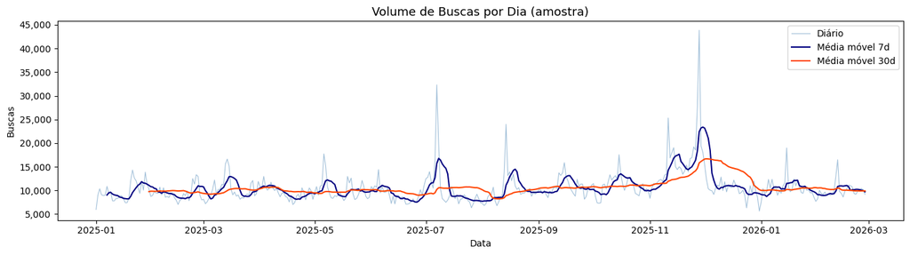

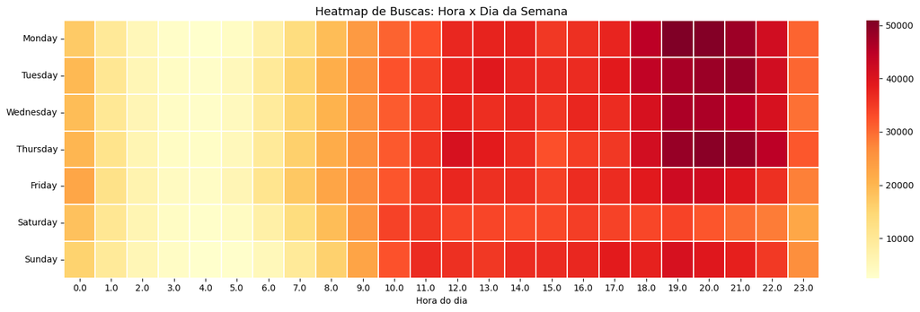

**Análise:**

i- Em relação à análise temporal das buscas, é possível observar que há alguns períodos com maior procura. Tratando-se dos dados do shop, é perfeitamente esperado que tais padrões ocorram, como por exemplo: picos na primeira quinzena de maio (dia das mães), final de novembro (black friday) e no final do ano em geral (natal + ano novo);

ii- É interessante notar que os períodos mais intensos de buscas olhando para o padrão de hora do dia x dia da semana (heatmap) se concentram entre 19:00 e 21:00. Qualitativamente analisando, há menos buscas no horário comercial quando comparado ao período típico pós expediente.

## 2.2 Análise dos Termos Buscados

**Propósito:** A seguir, algumas análises qualitativas sobre os termos mais buscados são apresentadas. Essas análises buscam trazer um entendimento de quais os termos mais buscados, qual a concentração desses termos (há muitas pesquisas diversas, ou um número mais concentrados de termos representam boa parte do total?) e uma distribuição do tamanho dos prompts dos usuários (no shop, usuários tendem a ser mais ou menos "verbosos" em suas pesquisas?)

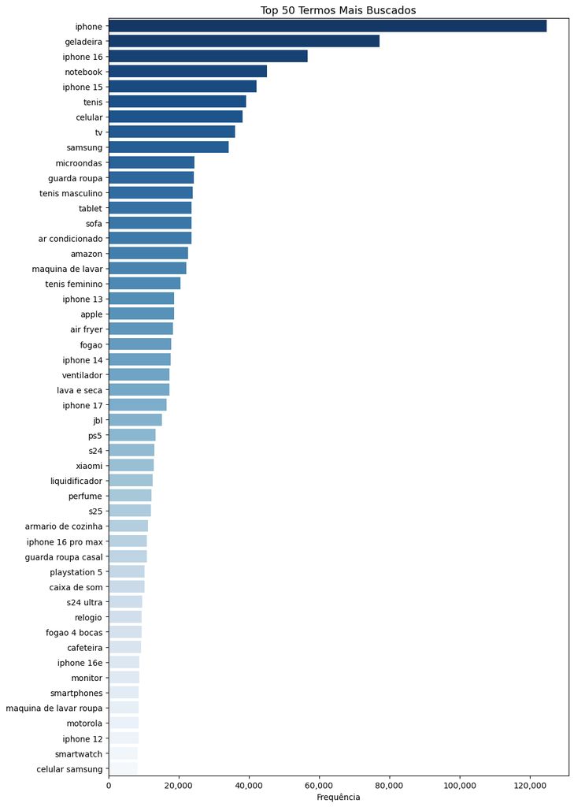

```
Análise de Pareto (threshold = 80%):
  14,580 termos (2.9%% dos únicos) cobrem 80% do volume total.
```

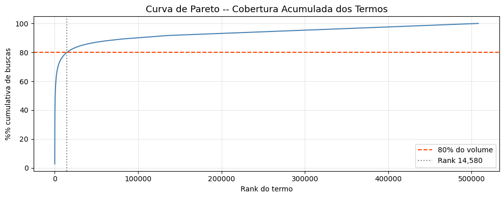

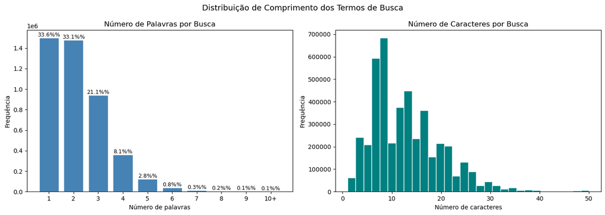

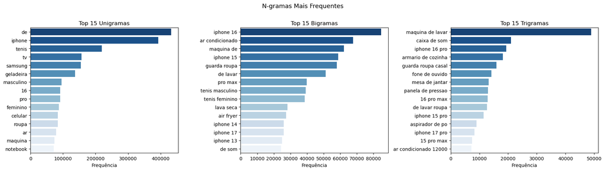

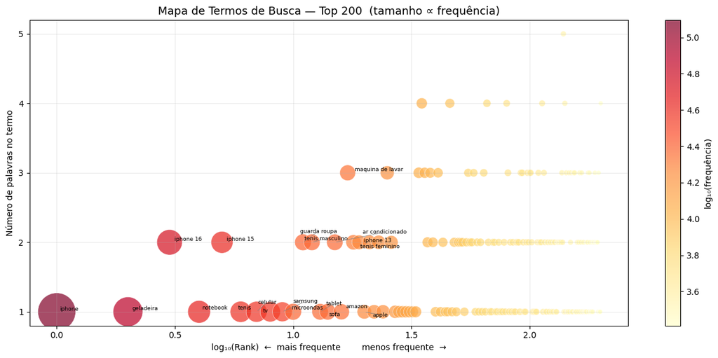

**Análise:**

i- Ao analisarmos a distribuição dos termos únicos de pesquisa, é possível ver que há um grande concentração de buscas que se concentram em: telefones (iphones, linha galaxy sX, Xiaomi), eletrodomésticos, eletrônicos em geral e vestuário.

ii- Há uma concentração razoável dos termos mais buscados em relação ao total --- uma fronteira de pareto. Temos que **2.9% dos termos únicos** buscados representam um volume de **80% do total** das buscas;

iii- As buscas são, majoritariamente, feitas por **termos curtos**. Temos que **66.7%** das buscas utilizam **até duas palavras**, sendo **87.8%** do total das buscas tendo **até três palavras**. Tal número traz um indicativo que: boa parte das buscas no shopping não são bem explicitadas, são buscas mais abertas.

## 2.3 Segmentação por Plataforma e Segmento de Produto

**Propósito:** Identificar diferenças de comportamento entre plataformas (iOS/Android) e segmentos de produto (DIGITAL, ONE, BLACK, WIN).

```
Distribuição por plataforma:
platform
ANDROID    3063830
IOS        1404590
```

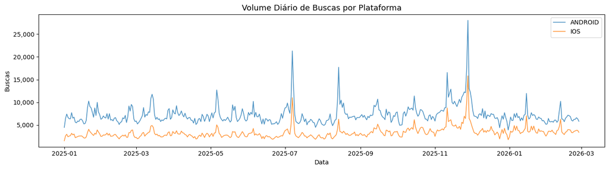

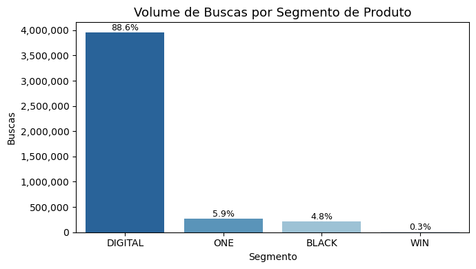

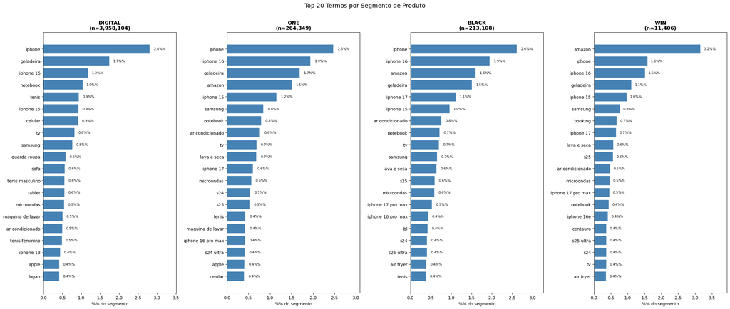

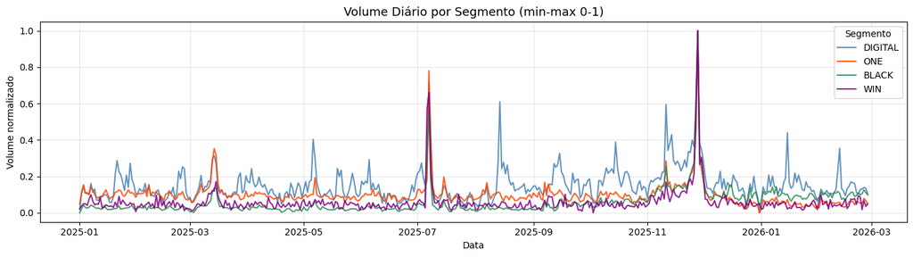

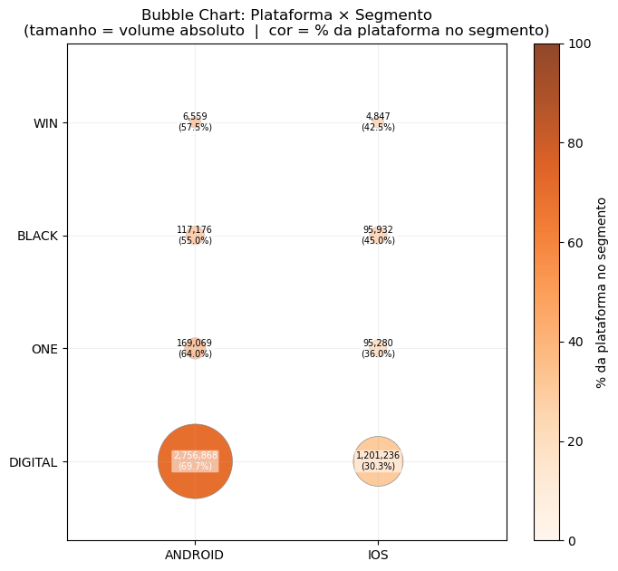

**Análise:**

i- Analisando as buscas diárias segmentadas por dispositivos, não há padrões tão distintos entre os dois segmentos. Isso traz um indício que: utilizar informações de sazonalidade para gerar recomendações por segmento pode não trazer impactos;

ii- A maioria das buscas (88.6%) são feitas por clientes do segmento **DIGITAL**. Esse resultado é coerente com as distribuição de clientes na base total;

iii- Ao analisarmos os termos mais buscados por cada segmento, as seguintes discrepâncias podem ser observadas: a- Uma incidência maior do termo "Amazon" nos segmentos ONE, BLACK e WIN --- quando comparados ao segmento DIGITAL. Vale entender se há algum benefício (gift card, cupom algo do tipo) oferecido aos clientes dessas categorias que apresentam maior volume de busca, ou se é um padrão de algum outro comportamento; b- As buscas feitas pelo segmento DIGITAL compreendem um número muito maior de categorias do que as buscas feitas pelos demais segmentos. Devido à discrepância entre o número de buscas feitas por clientes nesta categoria comparada às demais, esse resultado é coerente; c- Os segmentos ONE e BLACK apresentam um padrão de busca mais voltado para Eletrônicos.

# 3. Análise Qualitativa (Classificação LLM)

## 3.1 Etapa 1 -- Descoberta de Categorias

**Propósito:** Enviar uma amostra estratificada ao LLM com prompt aberto para sugerir categorias e intenções. O resultado é salvo em cache JSON; nas execuções subsequentes o LLM **não** é chamada novamente.

É possível explorar as Categorias e Intenções de busca definidas abaixo

**Categorias de Busca**

**Móveis e Decoração para o Lar**

**Descrição:** Agrupa buscas por itens de mobiliário residencial, decoração de ambientes e organização doméstica

**Exemplos:** cama box king, armario de aco, mesa jantar, guarda roupa 6 portas, painel ripado

**Eletrônicos e Tecnologia**

**Descrição:** Reúne dispositivos eletrônicos pessoais, computadores, periféricos e acessórios tecnológicos

**Exemplos:** macbook m4, iphone 16 pro max, samsung notebook, smartwatch amazfit, placa de video rtx 3060 12gb

**Moda e Vestuário**

**Descrição:** Engloba roupas, calçados, acessórios de moda e artigos de uso pessoal

**Exemplos:** tenis adidas preto, calca legging, bota de couro feminino, moletom masculino, sandalia melissa

**Eletrodomésticos**

**Descrição:** Concentra aparelhos domésticos de grande e pequeno porte voltados para cozinha, lavanderia e climatização

**Exemplos:** geladeira eletrolux inverse, lava e seca samsung, air fryer eletrolux, microondas 30 litros midea, ar condicionado 14000

**Beleza, Saúde e Cuidados Pessoais**

**Descrição:** Abrange cosméticos, produtos capilares, perfumes, higiene e bem-estar

**Exemplos:** shampoo e condicionador wella, body splash natura, protetor solar facial la roche pose, mascara capilar lola, secador de cabelo taiff 110v

**Marcas e Lojas**

**Descrição:** Reúne buscas pelo nome de marcas ou redes varejistas, indicando intenção de navegar diretamente para um seller ou vitrine

**Exemplos:** zattini, netshoes, boticario, farmacia pague menos, localiza

**Ferramentas, Automotivo e Construção**

**Descrição:** Agrupa itens de uso profissional ou técnico, peças automotivas, ferramentas e materiais de construção

**Exemplos:** serra marmore makita, kit ferramentas, scanner automotivo, pneu aro 15 185 65, lixadeira 110

**Cozinha e Utilidades Domésticas**

**Descrição:** Engloba utensílios de cozinha, panelas, acessórios culinários e itens de uso cotidiano no lar

**Exemplos:** panela de pressao ceramica, forma de bolo, liquidificador power max, jogo de panela de inducao preta, panela cacarola tramontina 24cm

**Intenções de Busca**

**Busca por Produto Específico**

**Descrição:** O usuário sabe exatamente o que quer e busca com modelo, cor, capacidade ou especificação técnica detalhada

**Exemplos:** iphone 16 pro max 512gb, geladeira brastemp brm56fk, notebook dell inspiron i15 i1300 a15p core 3 8gb

**Exploração de Categoria**

**Descrição:** O usuário ainda está em fase de descoberta e busca por uma categoria ampla, sem produto definido

**Exemplos:** roupas femininas, moveis de cozinha, eletrodomesticos vermelho

**Navegação por Marca ou Loja**

**Descrição:** O usuário quer acessar diretamente o catálogo de uma marca ou loja parceira, usando o buscador como atalho de navegação

**Exemplos:** boticario, netshoes, adidas masculino

**Recompra ou Produto de Rotina**

**Descrição:** O usuário busca itens de consumo recorrente, sugerindo reposição de produtos já conhecidos

**Exemplos:** racao cachorro, sabao liquido, repelente de mosquito

## 3.2 Etapa 2 -- Classificação

**Propósito:** Classificar todos os termos únicos usando abordagem híbrida: LLM rotula conjunto de treino (2a), SentenceTransformer gera embeddings com cache (2b), LogisticRegression local prediz o vocabulário completo (2c).

Alguns exemplos das buscas classificadas são apresentados abaixo. O campo "Confiança da categorização" diz respeito a: o quão certo o modelo está que a "Categoria de busca" foi corretamente definida. Nesse momento, um pequeno grupo de amostras foi processado por uma LLM para atribuição da categoria de busca e intenção de busca. Nas células a seguir, um outro modelo (uma regressão logística) foi utilizada para realizar tal categorização em maior escala.

```
Termos classificados: 600  |  ERROs: 0
```

|  | Termo buscados | Categoria da busca (gerada pelo modelo) | Intenção da busca (gerada pelo modelo) | Confiança da categorização |
| --- | --- | --- | --- | --- |
| 0 | iphone | Eletrônicos e Tecnologia | Navegação por Marca ou Loja | alta |
| 1 | geladeira | Eletrodomésticos | Exploração de Categoria | alta |
| 2 | iphone 16 | Eletrônicos e Tecnologia | Busca por Produto Específico | alta |
| 3 | notebook | Eletrônicos e Tecnologia | Exploração de Categoria | alta |
| 4 | iphone 15 | Eletrônicos e Tecnologia | Busca por Produto Específico | alta |
| 5 | tenis | Moda e Vestuário | Exploração de Categoria | alta |
| 6 | celular | Eletrônicos e Tecnologia | Exploração de Categoria | alta |
| 7 | tv | Eletrônicos e Tecnologia | Exploração de Categoria | alta |
| 8 | samsung | Marcas e Lojas | Navegação por Marca ou Loja | alta |
| 9 | microondas | Eletrodomésticos | Exploração de Categoria | alta |

A seguir, o treinamento do classificador é feito para uma maior massa de dados.

```
Termos de treino validos: 600  (descartados 0 ERROs)
Treinando classificador de categoria...
Treinando classificador de intencao...
Classificando 508,106 termos...
categoria
Eletrônicos e Tecnologia                150710
Eletrodomésticos                        140177
Móveis e Decoração para o Lar            67891
Moda e Vestuário                         55979
Marcas e Lojas                           44854
Beleza, Saúde e Cuidados Pessoais        27372
Ferramentas, Automotivo e Construção     15828
Cozinha e Utilidades Domésticas           5295
```

|  | Termo buscados | Categoria da busca (gerada pelo modelo) | Intenção da busca (gerada pelo modelo) | Confiança da categorização |
| --- | --- | --- | --- | --- |
| 0 | iphone | Eletrônicos e Tecnologia | Exploração de Categoria | alta |
| 1 | geladeira | Eletrodomésticos | Exploração de Categoria | alta |
| 2 | iphone 16 | Eletrônicos e Tecnologia | Busca por Produto Específico | alta |
| 3 | notebook | Eletrônicos e Tecnologia | Exploração de Categoria | alta |
| 4 | iphone 15 | Eletrônicos e Tecnologia | Busca por Produto Específico | alta |
| 5 | tenis | Moda e Vestuário | Exploração de Categoria | alta |
| 6 | celular | Eletrônicos e Tecnologia | Exploração de Categoria | alta |
| 7 | tv | Eletrônicos e Tecnologia | Exploração de Categoria | alta |
| 8 | samsung | Marcas e Lojas | Navegação por Marca ou Loja | baixa |
| 9 | microondas | Eletrodomésticos | Exploração de Categoria | alta |

**Análise:**

i- O processo de descoberta indutiva via LLM gerou uma taxonomia de 8 categorias e 4 intenções que cobrem adequadamente o perfil de um shopping de varejo digital, com destaque para a separação entre intenções transacionais de alto envolvimento ("Busca por Produto Específico") e intenções exploratórias abertas ("Exploração de Categoria");

ii- O classificador atribuiu confiança "baixa" ao termo "samsung" — único caso no Top 10 com esse comportamento — o que é esperado dado o caráter ambíguo do termo (marca e linha de produto simultaneamente). Isso indica que o modelo captura corretamente casos de ambiguidade semântica;

iii- É interessante notar que o rótulo de intenção "Busca por Produto Específico" foi atribuído a casos, de fato, muito específicos. Como por exemplo, o termo "iphone" é atribuído a "Exploração de Categoria", ao passo que, "iphone 16" é atribuído a "Busca por Produto Específico".

# 4. Análises Cruzadas

**Propósito:** Combinar classificações LLM com dados de comportamento para responder: quais categorias dominam, como intenções se relacionam com categorias, e como essas dimensões variam por segmento.

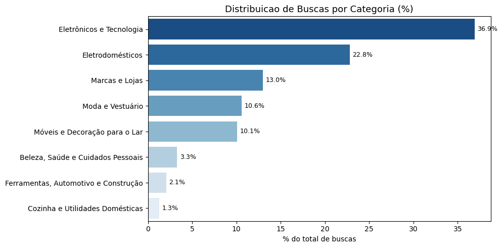

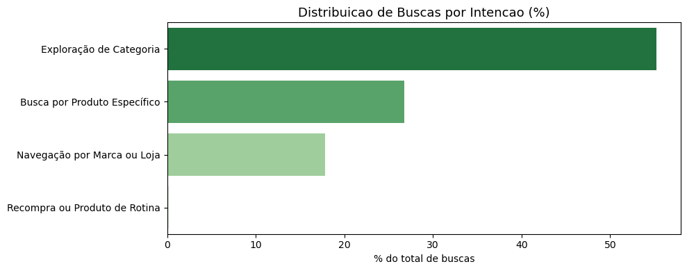

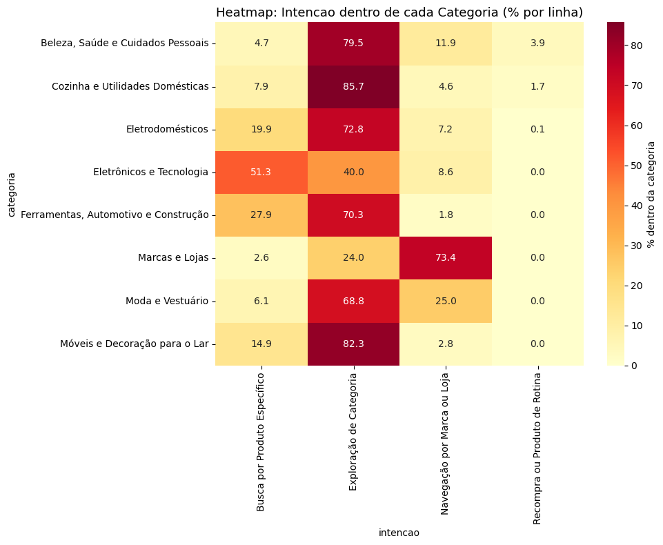

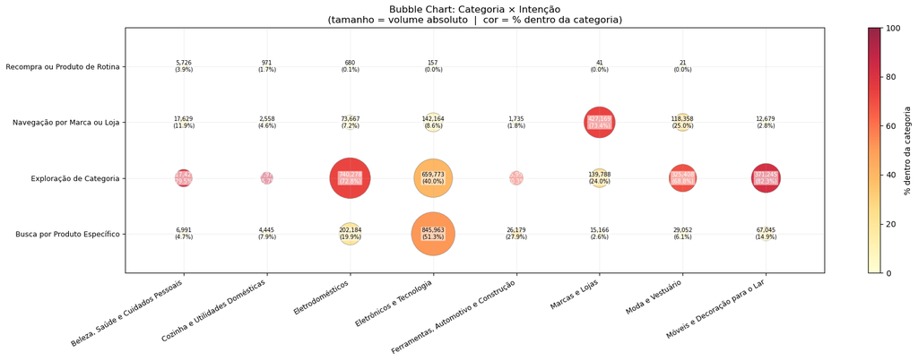

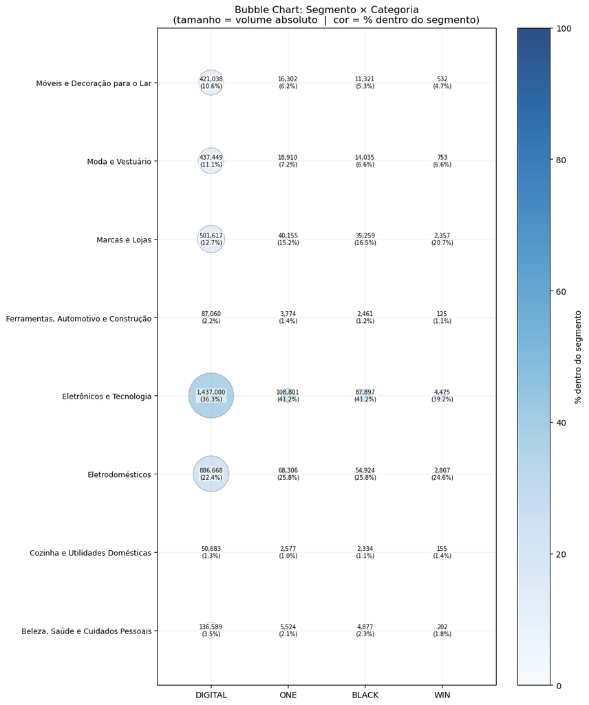

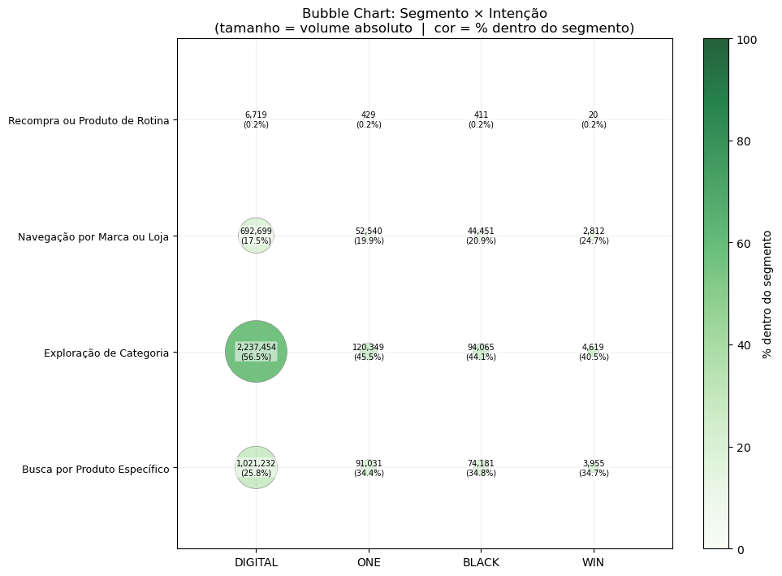

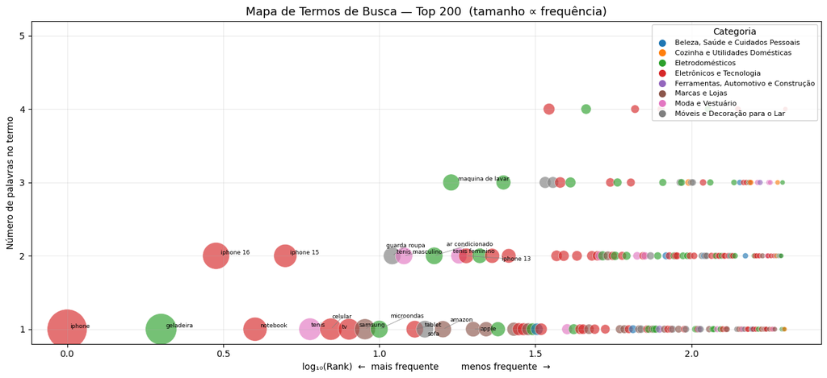

**Análise**

i- A combinação das classificações com os dados de segmento confirma que Eletrônicos e Tecnologia é a categoria dominante em volume, especialmente nos segmentos premium (ONE e BLACK), onde o padrão de busca é mais concentrado nessa categoria do que no segmento DIGITAL;

ii- A intenção "Exploração de Categoria" é majoritária no Top 10 por volume (geladeira, notebook, celular, tv, microondas), indicando que a maior parte das buscas de alto volume são abertas — o que reforça a importância de uma camada de ranqueamento e recomendação robusta para guiar o usuário até a conversão;